# Homework 04

Xiao, Justin (email: BOX11@pitt.edu)

today

# Overview

> In this assignment, You will use two datasets: the DJI(Dow Jones Index) data of stock price, and the political book co-purchase dataset for this assignment.

**Problem 1**. analyze the data of stock price: DJI.csv (included in the repository). The dataset contains historical price of stocks. Each column of the dataset is a stock and their code name is on the first row. The objective of the analysis is to group stocks together if they have similar trends in price.

1. Use PCA to reduce the dimension of stock-price information. Generate a scree plot and determine the number of principle components based on this plot. Plot the loadings for first principal component.  
   **hint:** Standardize the data before doing PCA. Specifically, make the stocks to be the unit (rows) of analysis, and standardize it for columns to be in the same scale, using `t` and `scale` in R. You will loose 2 points if you directly perform PCA without standardize the data.
2. Generate a scatter plot to that shows the projected stock prices (labeled with stock codes) on the first two principal components as x- and y-axes.
3. Generate an MDS map to plot stocks on a two-dimensional space.
4. Use k-means and hierarchical clustering to group stocks. Specifically, you will generate 8 MDS maps for the stocks and color the stocks based on different clustering methods: k-means with different number of clusters(k=4, k=8), h-clustering with single-link using different number of clusters(k=4, k=8), h-clustering with complete-link using different number of clusters(k=4, k=8), h-clustering with average-link using different number of clusters(k=4, k=8). For each hierarchical clustering method, generate a dendrogram.

**Problem 2**. analyze “Books about US Politics” data. The objective is to identify and visualize the clustering patterns of political books’ co-purchase activities. The original data was compiled from an online bookseller on Amazon.com, by V. Krebs [link](http://www.orgnet.com/divided.html).You will use two files of processed data for this task:

**bookinfo.csv** (included in the repository): contains the name and class for each book. Books have been given values 1, 2, or 3 to indicate whether they are “liberal”, “neutral”, or “conservative” repectively. (Note: in this assignment, we only include “liberal” and “conservative” books here.)  
**bookcopurchase.csv** (included in the repository): shows whether two books were “co-purchased” by the same buyers (0: not purchased together; 1: purchased together)

1. Create a book-by-book distance matrix. Generate an MDS plot to project the books with their names on a two dimensional space. Use shapes or color to differentiate the books’ Class (liberal or conservative).
2. Use K-means and hierarchical clustering to group books with their names, and color the books on the MDS plots based on the clustering results (you will need to use k-means,h-clustering with single-link, h-clustering with complete-link, h-clustering with average-link and k=2)
3. Compare the clustering results with the Class labels and identify books in a certain class that are assigned to a seemly wrong cluster. Specifically, based on k-means results, which liberal books are clustered together with conservative books, and vice versa? And based on the three variance (single-link, complete-link, average-link), which liberal books are clustered together with conservative books, and vice versa? (Note: you can just identify 2-3 books, no need to list all of them)
4. Compute the purity and entropy for these clustering results with respect to the books’ class labels. You will need to generate a 2×4 table as follows:

| Measure/Method | k-means | hclust-single | hclust-complete | hclust-average |
| --- | --- | --- | --- | --- |
| purity |  |  |  |  |
| entropy |  |  |  |  |

5. Based on your observation on both measures and mis-classified members, choose two clustering methods that generate the most meaningful results and explain why.

# Problem 1:

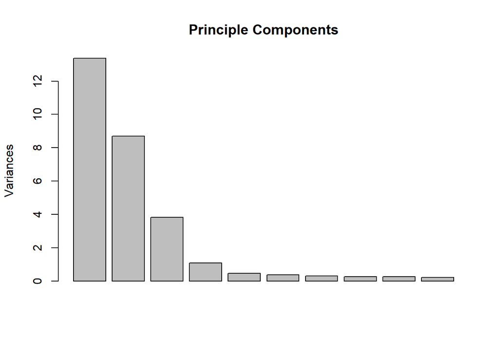

```r
## YOUR CODE HERE
set.seed(1)
DJI <- read.csv("DJI.csv")
RDJI <- t(DJI)

## A
pcaDJI = prcomp(DJI, scale = T)
DJIpc = predict(pcaDJI)
plot(pcaDJI, main="Principle Components")
```

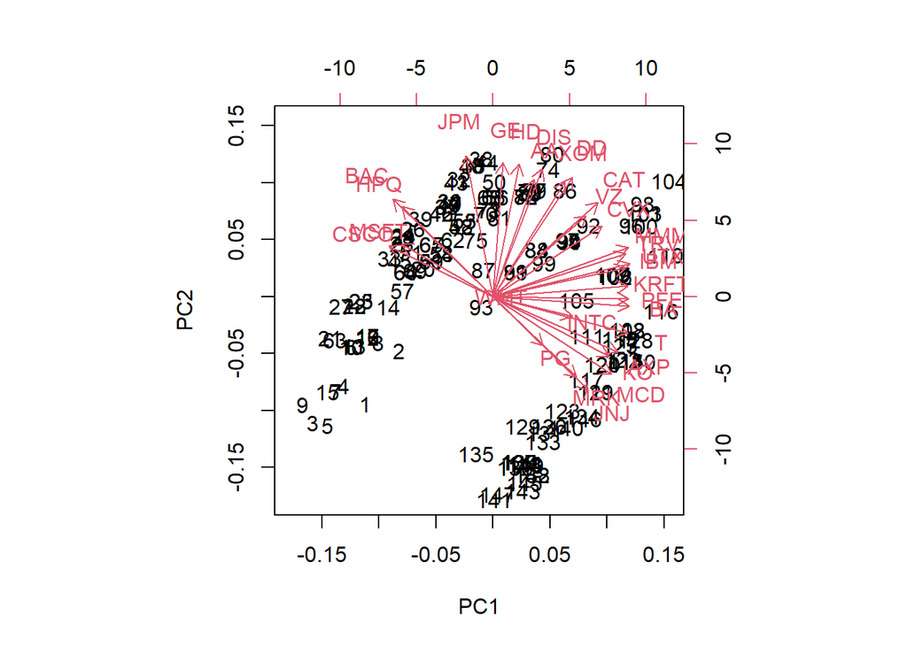

```r
## B
biplot(pcaDJI)
```

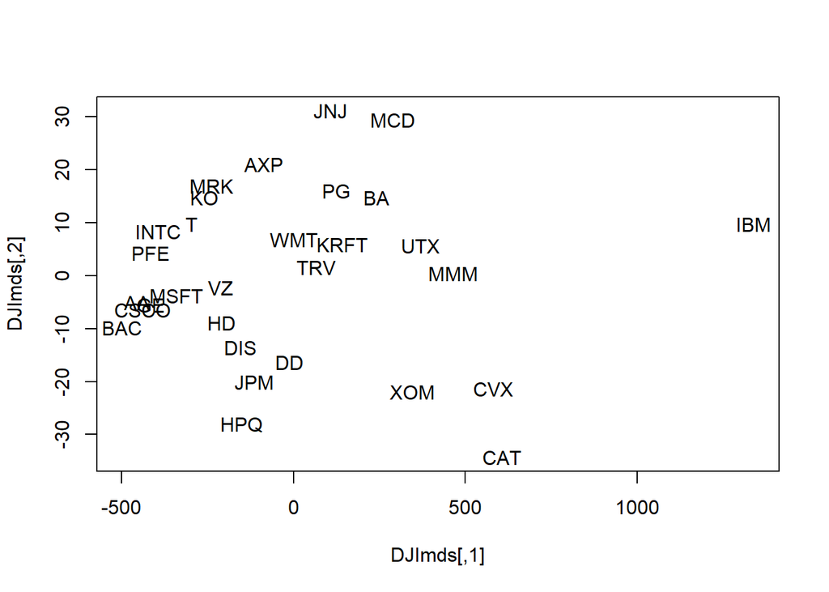

```r
## C
DJIdist = dist(RDJI)
DJImds <- cmdscale(DJIdist)
plot(DJImds, type = 'n')
text(DJImds, labels=row.names(RDJI))
```

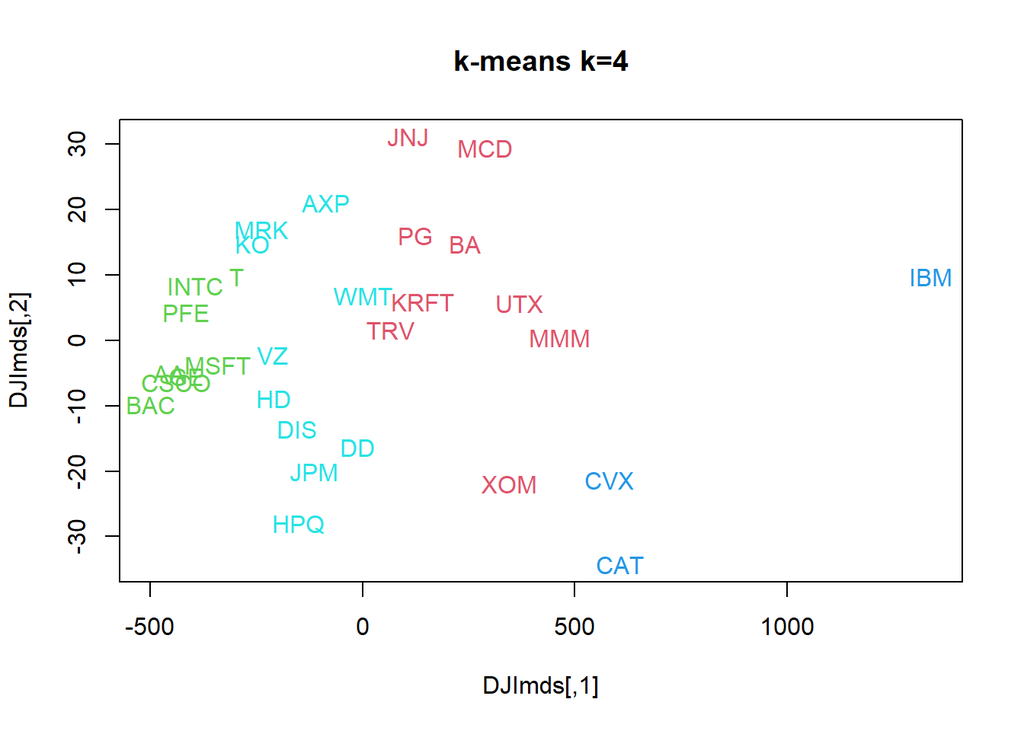

```r
## D
## kmeans
DJIkmeans4 = kmeans(RDJI, centers=4)
DJIkmeans8 = kmeans(RDJI, centers=8)
plot(DJImds, main="k-means k=4", type = 'n')
text(DJImds, labels=row.names(RDJI), col = DJIkmeans4$cluster+1)
```

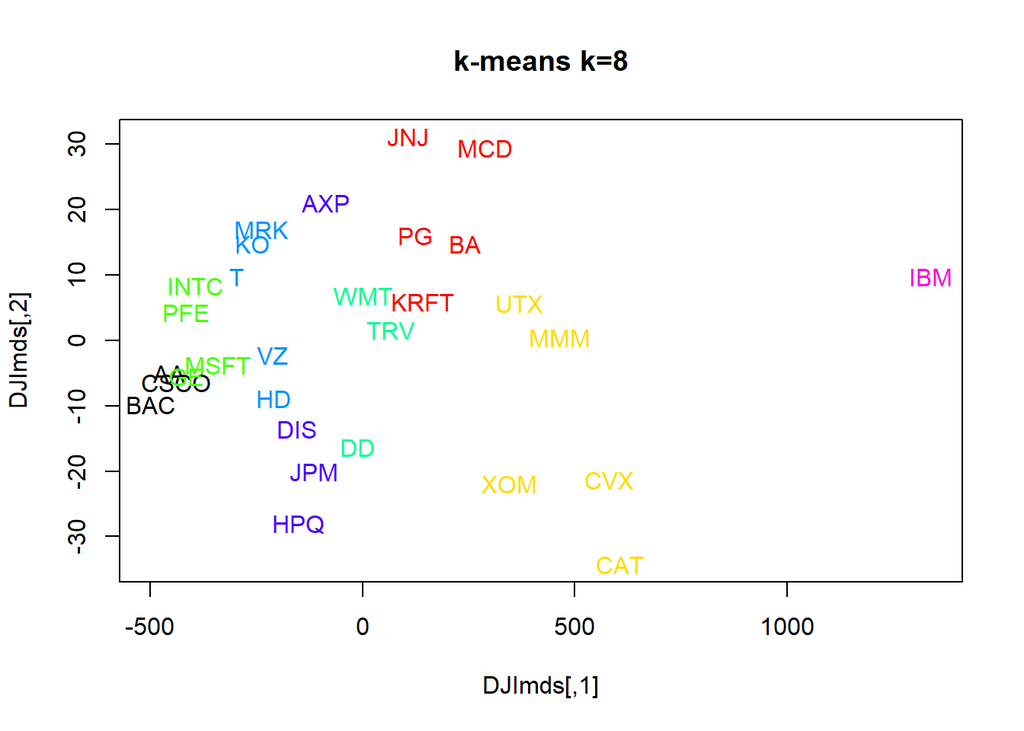

```r
plot(DJImds, main="k-means k=8", type = 'n')
text(DJImds, labels=row.names(RDJI), col = rainbow(7)[DJIkmeans8$cluster])
```

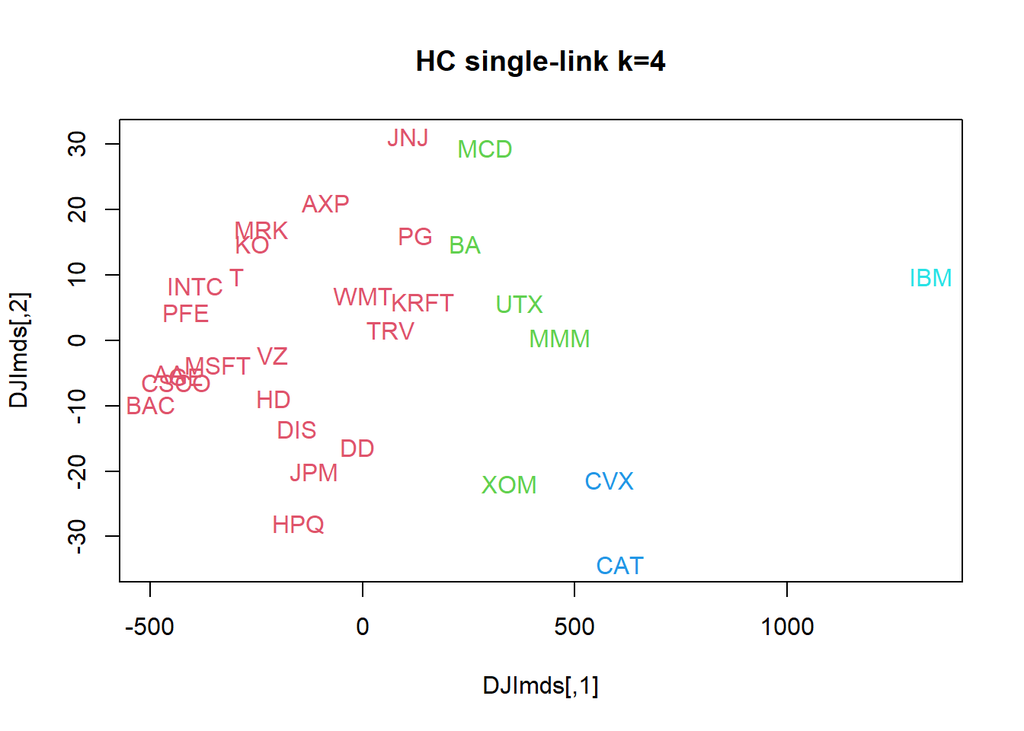

```r
HCsgle = hclust(DJIdist, method = 'single')
HCcomp = hclust(DJIdist, method = 'complete')
HCaveg = hclust(DJIdist, method = 'average')
HCsgle4 = cutree(HCsgle, k = 4)
plot(DJImds, main="HC single-link k=4", type = 'n')
text(DJImds, labels=row.names(RDJI), col = HCsgle4+1)
```

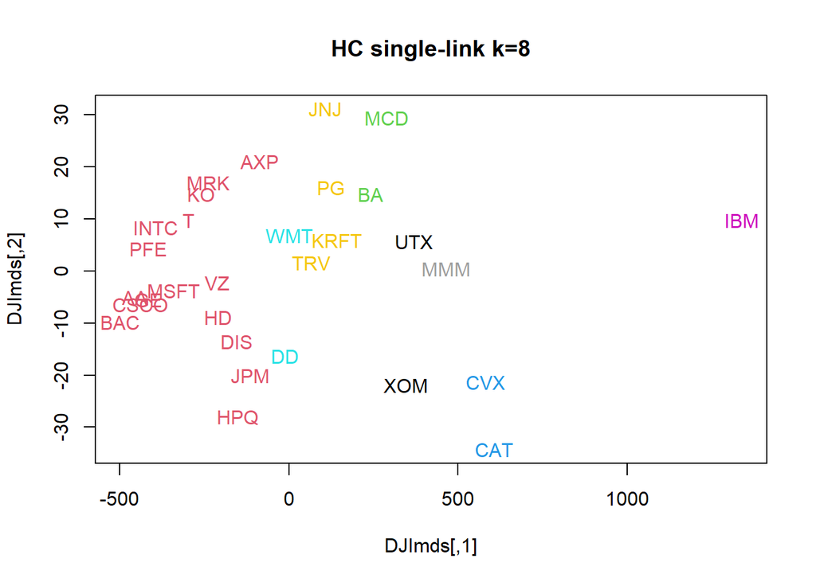

```r
HCsgle8 = cutree(HCsgle, k = 8)
plot(DJImds, main="HC single-link k=8", type = 'n')
text(DJImds, labels=row.names(RDJI), col = HCsgle8+1)
```

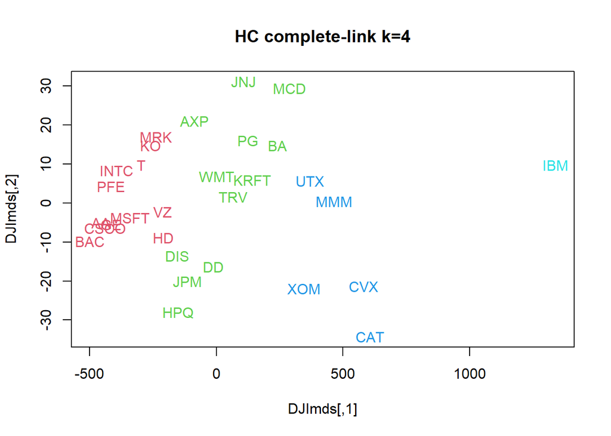

```r
HCcomp4 = cutree(HCcomp, k = 4)
plot(DJImds, main="HC complete-link k=4", type = 'n')
text(DJImds, labels=row.names(RDJI), col = HCcomp4+1)
```

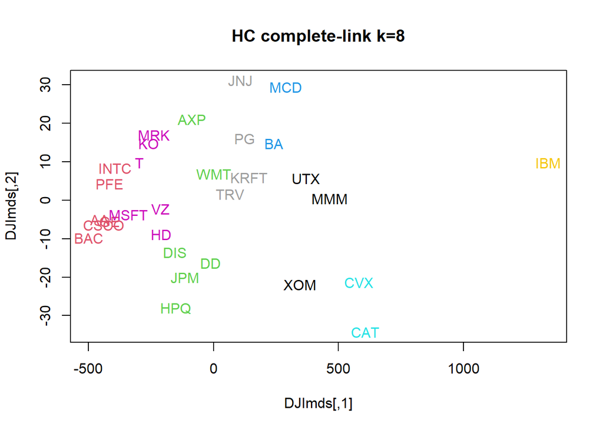

```r
HCcomp8 = cutree(HCcomp, k = 8)
plot(DJImds, main="HC complete-link k=8", type = 'n')
text(DJImds, labels=row.names(RDJI), col = HCcomp8+1)
```

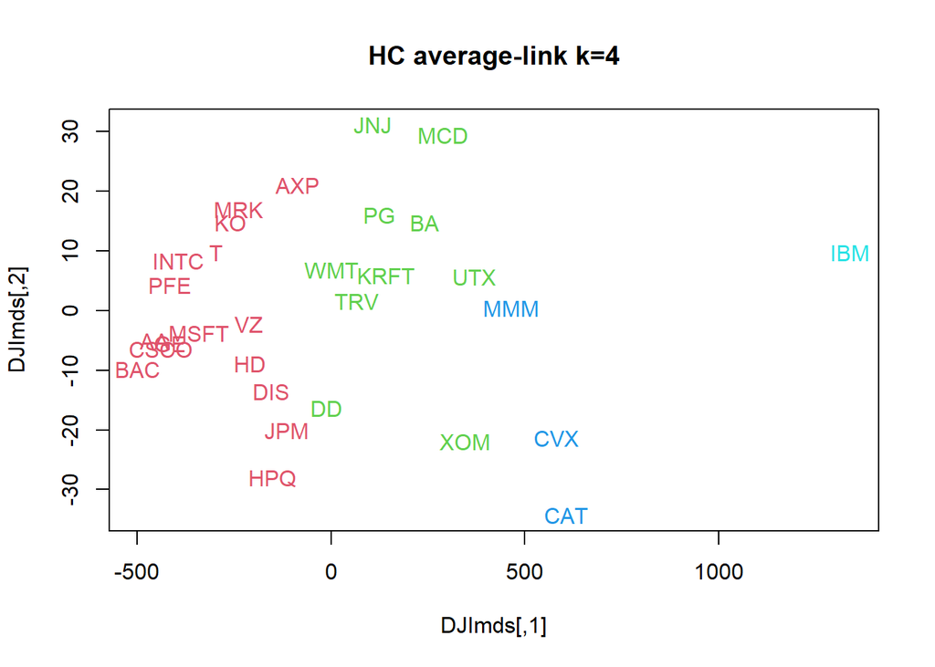

```r
HCaveg4 = cutree(HCaveg, k = 4)
plot(DJImds, main="HC average-link k=4", type = 'n')
text(DJImds, labels=row.names(RDJI), col = HCaveg4+1)
```

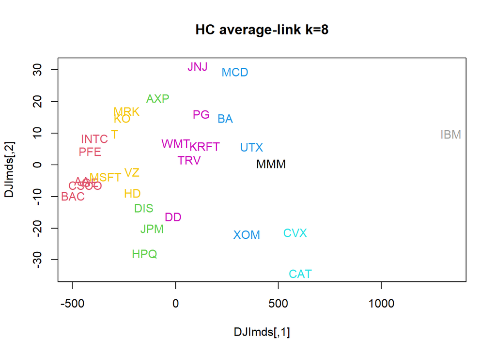

```r
HCaveg8 = cutree(HCaveg, k = 8)
plot(DJImds, main="HC average-link k=8", type = 'n')
text(DJImds, labels=row.names(RDJI), col = HCaveg8+1)
```

# Problem 2.

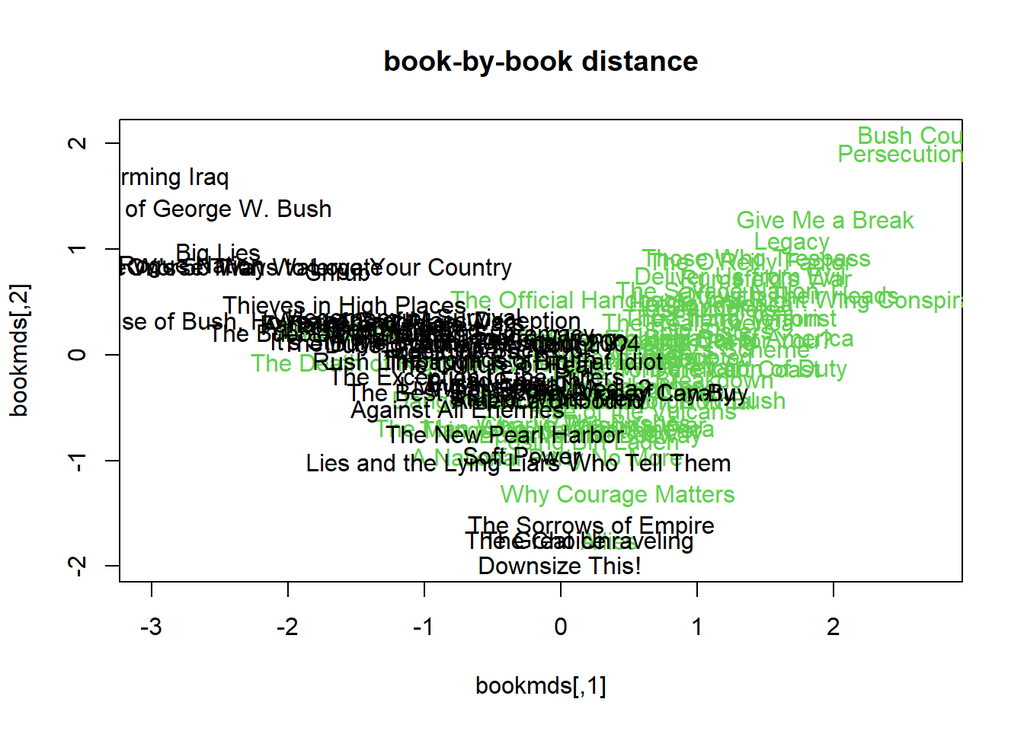

```r
## YOUR CODE HERE
bookCP <- read.csv("bookcopurchase.csv")
bookinfo <- read.csv("bookinfo.csv")
bookCPmtx <- bookCP[,-1]
bookinfoalt <- bookinfo

trans <- c(1,3,2, NA)
names(trans) <- c(1,2,3,NA)
bookinfoalt$Class <- trans[bookinfoalt$Class]

## A
bookdist = dist(bookCPmtx)
bookmds <- cmdscale(bookdist)

plot(bookmds, main="book-by-book distance", type = 'n')
text(bookmds, labels=bookinfo$name, col = bookinfo$Class)
```

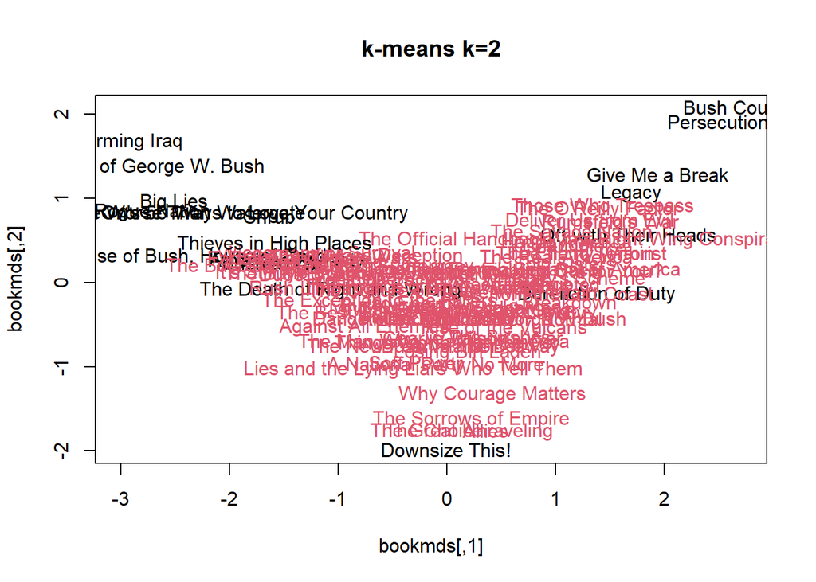

```r
## B
bookkmeans2 = kmeans(bookdist, centers=2)

plot(bookmds, main="k-means k=2", type = 'n')
text(bookmds, labels=bookinfo$name, col = bookkmeans2$cluster)
```

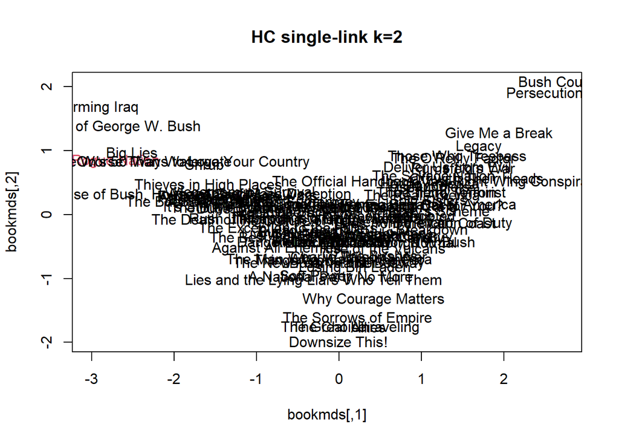

```r
HCsgle = hclust(bookdist, method = 'single')
HCcomp = hclust(bookdist, method = 'complete')
HCaveg = hclust(bookdist, method = 'average')

HCsgle2 = cutree(HCsgle, k = 2)
HCcomp2 = cutree(HCcomp, k = 2)
HCaveg2 = cutree(HCaveg, k = 2)

plot(bookmds, main="HC single-link k=2", type = 'n')
text(bookmds, labels=bookinfo$name, col = HCsgle2)
```

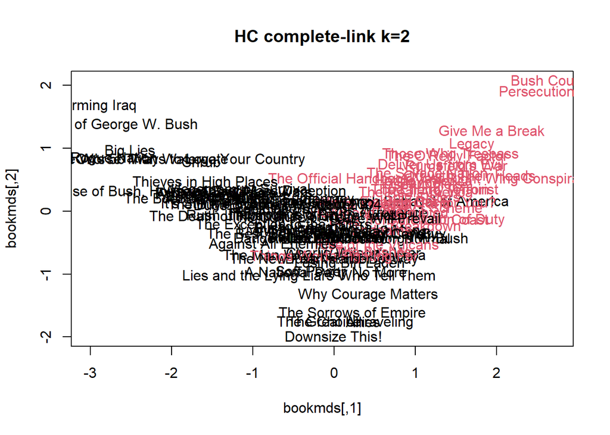

```r
plot(bookmds, main="HC complete-link k=2", type = 'n')
text(bookmds, labels=bookinfo$name, col = HCcomp2)
```

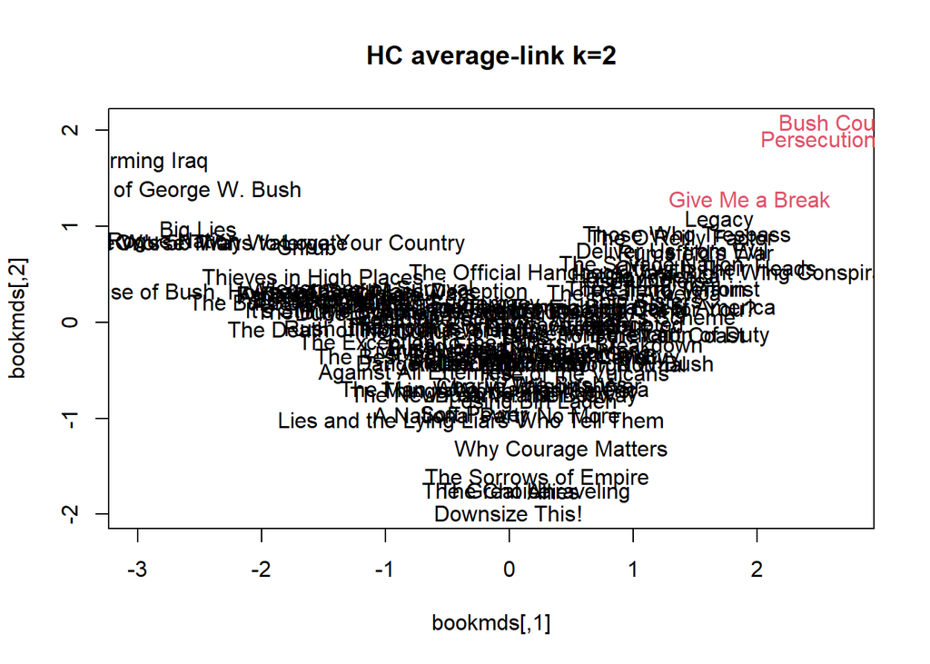

```r
plot(bookmds, main="HC average-link k=2", type = 'n')
text(bookmds, labels=bookinfo$name, col = HCaveg2)
```

```r
## D
cluster.purity <- function(clusters, classes) {
  sum(apply(table(classes, clusters), 2, max)) / length(clusters)
}

cluster.entropy <- function(clusters,classes) {
  en <- function(x) {
    s = sum(x)
    sum(sapply(x/s, function(p) {if (p) -p*log2(p) else 0} ) )
  }
  M = table(classes, clusters)
  m = apply(M, 2, en)
  c = colSums(M) / sum(M)
  sum(m*c)
}

statTable = matrix(
  c(cluster.purity(bookkmeans2$cluster,bookinfoalt$Class), cluster.purity(HCsgle2,bookinfoalt$Class), cluster.purity(HCcomp2,bookinfoalt$Class), cluster.purity(HCaveg2,bookinfoalt$Class),
    cluster.entropy(bookkmeans2$cluster,bookinfoalt$Class),
    cluster.entropy(HCsgle2,bookinfoalt$Class),
    cluster.entropy(HCcomp2,bookinfoalt$Class),
    cluster.entropy(HCaveg2,bookinfoalt$Class)),
  nrow = 2,
  ncol = 4,
  byrow = T
)
rownames(statTable) = c("purity", "entropy")
colnames(statTable) = c("k-means", "hclust-single", "hclust-complete", "hclust-average")
TableF <- as.table(statTable)
TableF
```

```
##           k-means hclust-single hclust-complete hclust-average
## purity  0.5652174     0.5434783       0.8043478      0.5326087
## entropy 0.9875482     0.9849043       0.5802929      0.9665983
```

YOUR ANSWER for Problem 2. E.Asw: In this situation, the hierarchical clustering with complete-link is most meaningful, since it has the largest purity and the lowest entropy.